# Homework 7

Diana Hackenburg

February 28, 2018

# Assignment: Creating Fake Data Sets To Explore Hypotheses

### My Hypothesis

I am interested in effects of three different framings about the impacts of cyanobacterial blooms on an individual’s support for action. I will be testing this (or a similar hypothesis) using an experimental survey distributed randomly in a single community. The four different impact framings, or treatments, are no additional infomation on impacts, ecosystem health, individual health, and cultural ecosystem services. The support for action would be measured through a combination of several statements answered using a 5-point likert scale, with 1 being completely disagree (no support for action) and 5 being completely agree (complete support for action).

From previous observations, I believe the no additional information treatment will have the lowest support for action but that it will still be closer to no opinion (3) than to complete disagreement (1). The ecosystem health treatment may have a slighly higher level of support for action due to the fact that it is supplying some additional informtion about the blooms. I think the individual impact treatment will be even higher, with clear support for action, and that the cultural ecosystem service treatment will have the highest level of support for action.

Our goal is to survey at least 500 households in the community, so I used this to set the starting sample sizes for each treatment (120,112,132,136). Taking the above argument, I set the starting means at 2.8,3,3.2, and 3.3. I based the starting standard deviations on similar surveys looking at environmental concerns, attitudes, and behavioral intentions.

### My Fake Dataset

```r
library(ggplot2)
nGroup <- 4
nName <- c("No Additional Information","Ecological Framing","Individual Health Framing","Cultural Ecosystem Services Framing")
nSize <- c(120,112,132,136)
nMean <- c(2.8,3,3.2,3.3)
nSD <- c(.55,.54,.52,.53)
ID <- 1:(sum(nSize))
resVar <-c(rnorm(n=nSize[1],mean=nMean[1],sd=nSD[1]),rnorm(n=nSize[2],mean=nMean[2],sd=nSD[2]),rnorm(n=nSize[3],mean=nMean[3],sd=nSD[3]),rnorm(n=nSize[4],mean=nMean[4],sd=nSD[4]))
TGroup <- rep(nName,nSize)
ANOVAdata <- data.frame(ID,TGroup,resVar)
ANOVAmodel <- aov(resVar~TGroup,data=ANOVAdata)
summary(ANOVAmodel)
```

```
##              Df Sum Sq Mean Sq F value   Pr(>F)
## TGroup        3  20.02   6.673    23.9 1.83e-14 ***
## Residuals   496 138.47   0.279
## ---
## Signif. codes:  0 '***' 0.001 '**' 0.01 '*' 0.05 '.' 0.1 ' ' 1
```

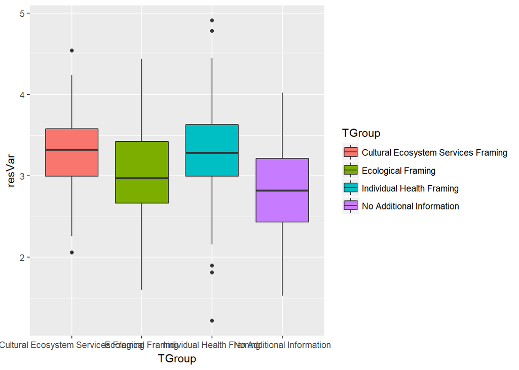

```r
ANOVAplot <- ggplot(data=ANOVAdata,aes(x=TGroup,y=resVar,fill=TGroup)) + geom_boxplot()
ANOVAplot
```

### Adjusting the means

*How small can the differences between the groups be to still detect a significant pattern (p < 0.05)?*

With my starting sample size and variances, the means (differences between the groups) could definitely be smaller and still detect a pattern (a statistically significant difference between some of the means). Here is an example of a compressed difference between groups:

```r
nGroup <- 4
nName <- c("No Additional Information","Ecological Framing","Individual Health Framing","Cultural Ecosystem Services Framing")
nSize <- c(120,112,132,136)
nMean <- c(2.94,3,3.07,3.13)
nSD <- c(.55,.54,.52,.53)
ID <- 1:(sum(nSize))
resVar <-c(rnorm(n=nSize[1],mean=nMean[1],sd=nSD[1]),rnorm(n=nSize[2],mean=nMean[2],sd=nSD[2]),rnorm(n=nSize[3],mean=nMean[3],sd=nSD[3]),rnorm(n=nSize[4],mean=nMean[4],sd=nSD[4]))
TGroup <- rep(nName,nSize)
ANOVAdata <- data.frame(ID,TGroup,resVar)
ANOVAmodel <- aov(resVar~TGroup,data=ANOVAdata)
summary(ANOVAmodel)
```

```
##              Df Sum Sq Mean Sq F value  Pr(>F)
## TGroup        3   4.91  1.6376   5.291 0.00134 **
## Residuals   496 153.51  0.3095
## ---
## Signif. codes:  0 '***' 0.001 '**' 0.01 '*' 0.05 '.' 0.1 ' ' 1
```

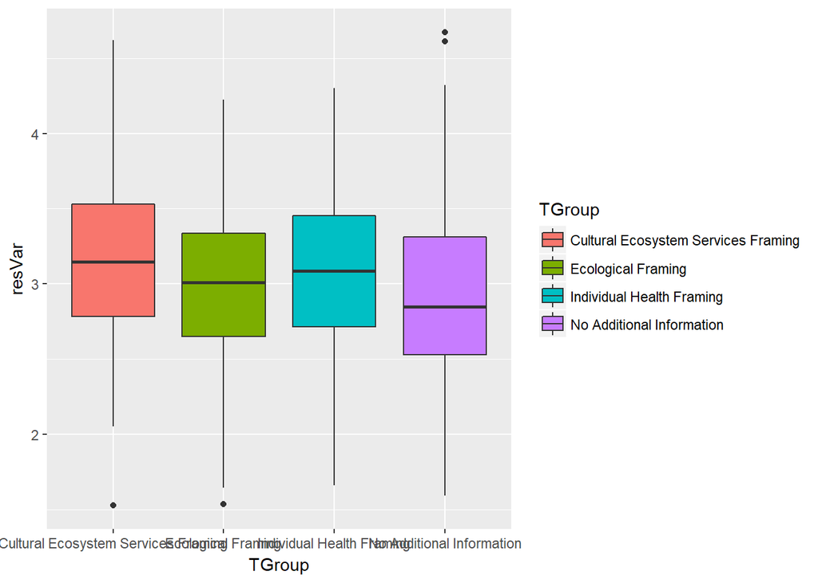

```r
ANOVAplot <- ggplot(data=ANOVAdata,aes(x=TGroup,y=resVar,fill=TGroup)) + geom_boxplot()
ANOVAplot
```

### Adjusting the Sample Size

*What is the minimum sample size in order to detect a statistically significant effect?*

Given the starting means (which I think I estimated too spread out) and variances, I can reduce the sample sizes by a lot and still detect a statistically significant effect between some of the some of the means. Here is an example:

```r
nGroup <- 4
nName <- c("No Additional Information","Ecological Framing","Individual Health Framing","Cultural Ecosystem Services Framing")
nSize <- c(15,15,15,15)
nMean <- c(2.8,3,3.2,3.3)
nSD <- c(.55,.54,.52,.53)
ID <- 1:(sum(nSize))

resVar <-c(rnorm(n=nSize[1],mean=nMean[1],sd=nSD[1]),rnorm(n=nSize[2],mean=nMean[2],sd=nSD[2]),rnorm(n=nSize[3],mean=nMean[3],sd=nSD[3]),rnorm(n=nSize[4],mean=nMean[4],sd=nSD[4]))
TGroup <- rep(nName,nSize)
ANOVAdata <- data.frame(ID,TGroup,resVar)
ANOVAmodel <- aov(resVar~TGroup,data=ANOVAdata)
summary(ANOVAmodel)
```

```
##             Df Sum Sq Mean Sq F value Pr(>F)
## TGroup       3  2.365  0.7883   2.824 0.0469 *
## Residuals   56 15.633  0.2792
## ---
## Signif. codes:  0 '***' 0.001 '**' 0.01 '*' 0.05 '.' 0.1 ' ' 1
```

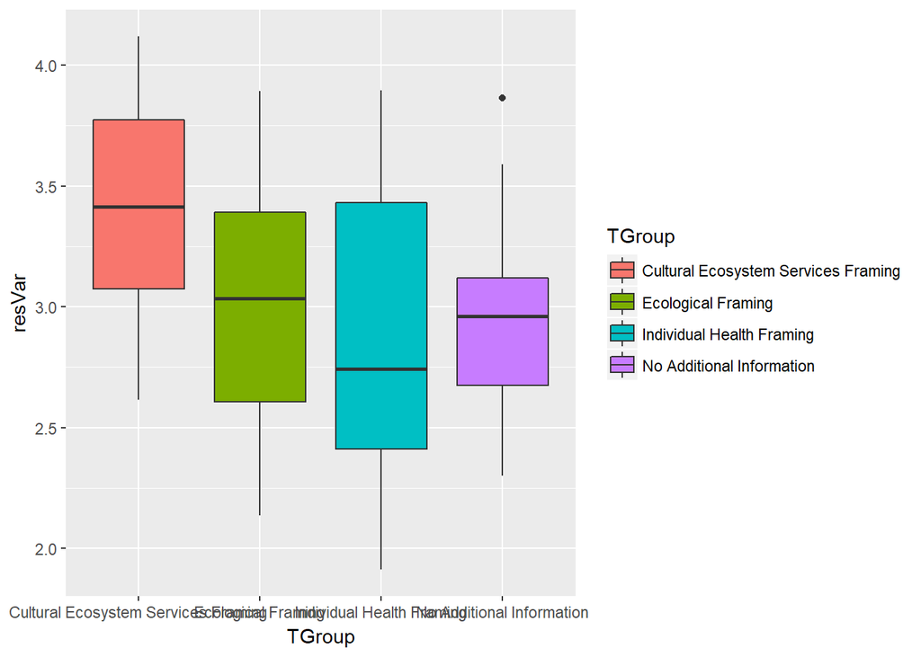

```r
ANOVAplot <- ggplot(data=ANOVAdata,aes(x=TGroup,y=resVar,fill=TGroup)) + geom_boxplot()
ANOVAplot
```